# S03 T05 Exploració de les dades-JM-Copy4

### Analysing cancelled flights

```python
temp_df1.loc[temp_df1['Cancelled'] == 0, 'Cancelled2'] = "No"
temp_df1.loc[temp_df1['Cancelled'] == 1, 'Cancelled2'] = "Sí"
```

```python
can= temp_df1['Cancelled2'].value_counts()
print (can)
```

```
No    1936125
Sí        633
Name: Cancelled2, dtype: int64
```

```
<function matplotlib.pyplot.show(close=None, block=None)>
```

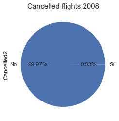

```python
can.plot(kind="pie",title="Cancelled flights",autopct='%1.2f%%')
plt.title("Cancelled flights 2008",
          fontsize = 15)

plt.show
```

```python
can2 = temp_df1['Cancelled2'] == "Sí"
carr= temp_df1['UniqueCarrier']
```

```python
can_carr= temp_df1[can2 & carr][:][['UniqueCarrier']].value_counts()
```

```python
print (can_carr)
```

```
UniqueCarrier
MQ               104
OO                89
9E                58
YV                53
UA                47
AA                46
XE                46
CO                38
EV                29
US                26
DL                21
NW                16
WN                15
OH                12
AS                11
B6                10
FL                 7
HA                 3
F9                 2
dtype: int64
```

```python
my_colors=['lightblue','lightgreen','silver','green']
```

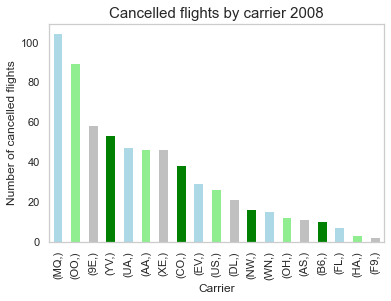

```python
can_carr.plot(kind="bar", color=my_colors, legend=False)
plt.xlabel("Carrier")
plt.ylabel('Number of cancelled flights')
plt.title("Cancelled flights by carrier 2008",
          fontsize = 15)

plt.show()
```

#### Envoy Air (MQ) and Skywest Airlines (OO) were the carriers with more cancelled flights.

### Analysis of flights' distribution by month, day of the month and carrier

```python
#Creating a function to plot Count plot
def count_plot(df,feature):
    sns.set(color_codes = 'lightgreen', style="whitegrid")
    sns.set_style("whitegrid", {'axes.grid' : False})
    sns.set_context(rc = {'patch.linewidth': 0.0})
    fig = plt.subplots(figsize=(10,3))
    sns.countplot(x=feature, data=df, palette = "tab10") # countplot
    plt.show()
```

```python
# Filter categorical variables
num_cols = temp_df1._get_numeric_data().columns
cols = temp_df1.columns
cat_cols = list(set(cols) - set(num_cols))
cat_cols
```

```
['DayofMonth',
 'CancellationCode',
 'Origin',
 'Dest',
 'Month',
 'DepDate',
 'Cancelled',
 'DayOfWeek',
 'UniqueCarrier',
 'Cancelled2']
```

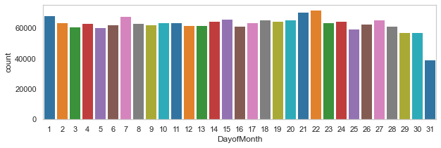

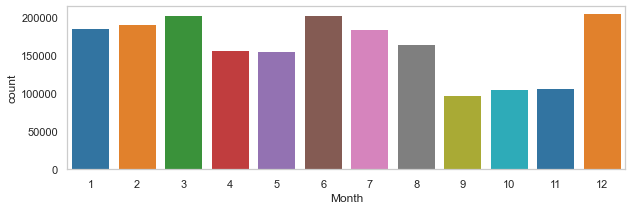

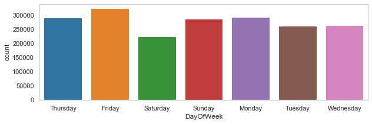

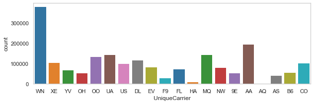

```python
for col in cat_cols:
    if col in ['UniqueCarrier','DayOfWeek','Month','DayofMonth']:
        count_plot(temp_df1,col)
```

### Analysis of flights destinations

```python
ori =temp_df1['Origin'].value_counts().head(10)
print (ori)
```

```
ATL    131613
ORD    125979
DFW     95414
DEN     74323
LAX     58772
IAH     56847
PHX     55720
LAS     53710
EWR     52925
DTW     43923
Name: Origin, dtype: int64
```

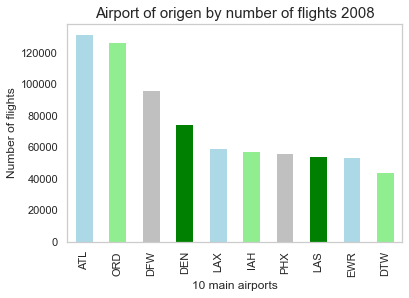

```python
ori.plot(kind="bar",title="Airport of origen",color=my_colors, legend=False, y="Number")

plt.xlabel("10 main airports")
plt.ylabel('Number of flights')
plt.title("Airport of origen by number of flights 2008",
          fontsize = 15)

plt.show()
```

```python
des =temp_df1['Dest'].value_counts().head(10)
print (des)
```

```
ORD    108984
ATL    106898
DFW     70657
DEN     63003
LAX     59969
EWR     55861
LAS     48858
PHX     47836
SFO     46876
IAH     43905
Name: Dest, dtype: int64
```

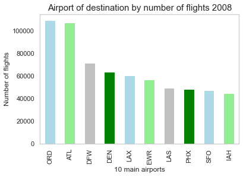

```python
des.plot(kind="bar",color=my_colors, legend=False, y="Number")

plt.xlabel("10 main airports")
plt.ylabel('Number of flights')
plt.title("Airport of destination by number of flights 2008",
          fontsize = 15)

plt.show()
```

```python
or_des = temp_df1.groupby(["Origin","Dest"], as_index=False)["DepDate"].count()
print (or_des)
```

```
     Origin Dest  DepDate
0       ABE  ATL      250
1       ABE  BHM        1
2       ABE  CLE       68
3       ABE  CLT       33
4       ABE  CVG       12
...     ...  ...      ...
5200    YUM  IPL       59
5201    YUM  LAS       25
5202    YUM  LAX      161
5203    YUM  PHX      333
5204    YUM  SLC      109

[5205 rows x 3 columns]
```

#### Number of possible flights combination 5205 by origin

```python
or_des2= or_des.sort_values('DepDate',ascending=False).head(10)
print (or_des2)
```

```
     Origin Dest  DepDate
2710    LAX  SFO     4739
3759    ORD  LGA     4396
227     ATL  LGA     4058
4613    SFO  LAX     4020
2585    LAS  LAX     3516
2749    LGA  ATL     3354
3727    ORD  EWR     3347
2789    LGA  ORD     3327
187     ATL  EWR     3283
1464    DFW  ORD     3278
```

```python
atl=or_des.loc[or_des['Origin'].isin(['ATL'])].sort_values('DepDate',ascending=False)
print (atl)
```

```
    Origin Dest  DepDate
227    ATL  LGA     4058
187    ATL  EWR     3283
233    ATL  MCO     3148
179    ATL  DFW     3094
257    ATL  ORD     2628
..     ...  ...      ...
190    ATL  FCA        7
238    ATL  MFE        5
171    ATL  CRP        3
205    ATL  GUC        1
302    ATL  TUP        1

[173 rows x 3 columns]
```

#### From Atlanta airport one can fly to 173 different destinations (domestic flights)

```python
atl2=or_des.loc[or_des['Origin'].isin(['ATL'])].sort_values('DepDate',ascending=False).head(10)
print (atl2)
```

```
    Origin Dest  DepDate
227    ATL  LGA     4058
187    ATL  EWR     3283
233    ATL  MCO     3148
179    ATL  DFW     3094
257    ATL  ORD     2628
191    ATL  FLL     2491
263    ATL  PHL     2308
299    ATL  TPA     2276
224    ATL  LAX     2081
177    ATL  DCA     2051
```

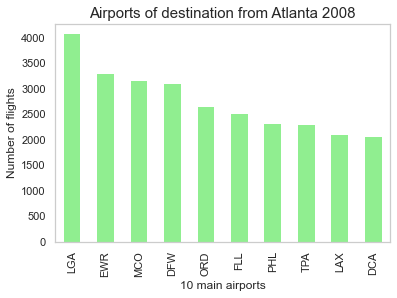

```python
atl2.plot(kind="bar", color = 'lightgreen', x="Dest", legend=False)
plt.xlabel("10 main airports")
plt.ylabel("Number of flights")
plt.title("Airports of destination from Atlanta 2008",
          fontsize = 15)

plt.show()
```

### Longest flights

```python
long=temp_df1.groupby(["Origin","Dest"], as_index=False)["AirTime"].mean()
long2=long.sort_values('AirTime',ascending=False).head(10)
print (long2)
```

```
     Origin Dest     AirTime
1737    EWR  HNL  605.981203
208     ATL  HNL  545.485531
2043    HNL  EWR  538.241379
3744    ORD  HNL  516.957143
3781    ORD  OGG  502.040541
2040    HNL  ATL  484.225806
3414    MSP  HNL  482.333333
2243    IAH  HNL  468.056047
1424    DFW  HNL  466.572000
1460    DFW  OGG  461.888889
```

#### The longest flights were, on average, from Newark International Airport, New Jersey (EWR) to Honolulu International Airport, Hawai(HNL), with 606 minutes, thus is, ten hours. The second longest was from Atlanta to Honololu.

### Save the data set to Excel (success at the third attempt)

#### First attempt

```python
temp_df1.to_excel('Delayed_flights_clean.xlsx', engine='xlsxwriter')
```

[output not shown]

#### Second attempt

```python
# Create a Pandas Excel writer using XlsxWriter as the engine.
writer = pd.ExcelWriter('delayed_flights_clean.xlsx', engine='xlsxwriter')
```

```python
# Convert the dataframe to an XlsxWriter Excel object.
temp_df1.to_excel(writer, sheet_name='delayed_flights_clean')
```

[output not shown]

```python
# Close the Pandas Excel writer and output the Excel file.
writer.save()
```

#### Third attempt

```python
df1 = temp_df1[0:1000000]
df2 = temp_df1[1000000:2000000]

print(df1,df2)
```

```
       Month DayofMonth DayOfWeek  DepTime  ArrTime UniqueCarrier  FlightNum  \
0          1          3  Thursday   2003.0   2211.0            WN        335
1          1          3  Thursday    754.0   1002.0            WN       3231
2          1          3  Thursday    628.0    804.0            WN        448
3          1          3  Thursday   1829.0   1959.0            WN       3920
4          1          3  Thursday   1940.0   2121.0            WN        378
...      ...        ...       ...      ...      ...           ...        ...
999995     6          8    Sunday   1659.0   1941.0            FL        474
999996     6          8    Sunday   1002.0   1158.0            FL         74
999997     6          8    Sunday   1525.0   1715.0            FL        776
999998     6          8    Sunday   1908.0   2056.0            FL         75
999999     6          8    Sunday   2130.0   2312.0            FL         79

        ActualElapsedTime  AirTime  ArrDelay  ...  CancellationCode Diverted  \
0                   128.0      116     -14.0  ...                 N        0
```

[output cut: 90 more lines]

```python
writer = pd.ExcelWriter('delayed_flights_clean.xls', engine='xlsxwriter',options={'encoding':'utf-8'})
df1.to_excel(writer,encoding='utf8', sheet_name='Sheet1')
df2.to_excel(writer, encoding='utf8',sheet_name='Sheet2')


writer.save()
```